# generar2020

```r
set.seed(1)
```

# Ejemplo 1: dos dados

Tiramos dos dados, queremos aproximar vía simulaciones, la probabilidad de que la suma dé 8

Queremos simular la tirada de dos dados. Para ello, usamos el comando `sample()`. `sample()` es una de las primeras funciones relevantes para simular. Para saber que hace esta función, basta tipear

```r
?sample
```

```
## starting httpd help server ... done
```

en la consola de comandos, y ver qué se abre en la ventana del help. Aparece un montón de información.

`sample()` toma hasta 4 argumentos, aunque solo el primero, `x` es fundamental.

`x` es el vector de elementos del cual uno quiere samplear (obtener observaciones).

`size` es el numero de observaciones que uno quiere obtener.

`replace` determina si uno está muestreando con o sin reposición (`replace = TRUE` para muestrear con reposición).

`prob` es un vector de pesos o probabilidades asociadas a x. Debería ser positivo y sus coordenadas sumar 1.

Para obtener un numero aleatorio entre 1 y 10 inclusive,

```r
sample(x = 1:10,size = 1)
```

```
## [1] 3
```

Cada vez que corremos la instrucción, obtenemos un resultado (potencialmente) distinto

```r
sample(x = 1:10,size = 1)
```

```
## [1] 1
```

Para obtener dos tiros del dado, hacemos

```r
sample(x = 1:6, size = 2, replace = TRUE) # tiramos dos dados
```

```
## [1] 5 5
```

Cada vez que corremos la instrucción, obtenemos un resultado distinto

```r
sample(x = 1:6, size = 2, replace = TRUE)
```

```
## [1] 2 6
```

```r
sample(x = 1:6, size = 2, replace = TRUE)
```

```
## [1] 6 2
```

Guardamos el resultado en un vector, que llamamos “dados”

```r
dados <- sample(x = 1:6, size = 2, replace = TRUE)
```

Vemos cuanto salió

```r
dados
```

```
## [1] 1 5
```

Ahora, cada vez que nos refiramos a “dados” estaremos trabajando con estos valores.

Veamos cuanto da la suma de los valores

```r
sum(dados)
```

```
## [1] 6
```

Armemos la indicadora de éxito, o sea, una funcion que valga 1 (o TRUE) si la suma es 8, y 0 (FALSE) sino

```r
sum(dados) == 8 # chequeamos si fuimos exitosos
```

```
## [1] FALSE
```

(equivale a la indicadora de éxito)

Ahora replicamos el código de arriba 20 veces. Para eso, creamos un vector donde guardar los resultados, inicialmente un vector con 20 ceros

```r
resultados <- rep(0,20)
```

El `for` es una instrucción sencilla de ciclo (loop). Comienza con el contador, (i en este caso) en el primer valor (i=1 en nuestro caso). Luego realiza lo que esta entre llaves, y cuando termina, aumenta el contador en una unidad (i=2) y vuelve a repetir la expresión que está entre llaves. Esto lo realiza hasta que el contador toma el último número (20 en nuestro caso) inclusive. Entre llaves le estamos pidiendo que repita: tirar dos veces un dado, sumarlos, chequear si vale 8 y anotar la indicadora de éxito en la coordenada correspondiente del vector resultados.

```r
for(i in 1:20){
  dados <- sample(x = 1:6, size = 2, replace = TRUE)
  resultados[i] <- sum(dados) == 8
}


resultados
```

```
##  [1] 0 0 0 0 0 0 0 1 1 1 0 0 0 0 1 0 0 0 1 0
```

```r
mean(resultados)  # frecuencia empirica o proporcion observada
```

```
## [1] 0.25
```

Calculemos la verdadera probabilidad que queremos aproximar. Sea Omega el conjunto de pares ordenados, con ambas coordenadas entre 1 y 6, definimos: A = {(2,6),(3,5),(4,4),(5,3),(6,2)}. Entonces P(A) = 5/36 = 0.1388889

```r
5/36
```

```
## [1] 0.1388889
```

Aumentamos el tamaño de muestra a 100000, y repetimos

```r
n <- 100000
resultados <- rep(0,n)

for(i in 1:n){
  dados <- sample(x = 1:6, size = 2, replace = TRUE)
  resultados[i] <- sum(dados) == 8
}

mean(resultados)
```

```
## [1] 0.13983
```

# Ejemplo 2: Cumpleaños (ejercicio Práctica 1)

> Se elige un grupo de r personas al azar y se les pregunta su fecha de cumpleaños. Si bien los años no son todos iguales en longitud, y se sabe que los porcentajes de nacimientos no son constantes a través del año, como una primera aproximación podemos suponer que una elección al azar de personas es equivalente a realizar una seleccion al azar de las fechas de nacimientos y además considerar que el año tiene 365 días. Bajo estas hipótesis, calcular la probabilidad de que entre las r personas elegidas al azar todas tengan distintas fechas de cumpleaños.

Llamemos $A_r$ al evento de interés. En la Práctica 1 probamos que
$$P(A_r) =365!/(365^r * (365-r)! )$$

- para $r=23, P(A_r) = 0.4927$
- para $r=30, P(A_r) = 0.29368$

Podemos armar una muestra de 23 cumpleaños, como antes

```r
sample(x = 1:365, size = 23, replace = TRUE)
```

```
##  [1]  17 346 112 289 247 203 105 246 183  66 112 332  49  78 272 213 232
## [18]  50 242 224 215  30 203
```

Interesa ver si se repiten. Para hacer esto, necesitamos poder determinar si todos los elementos en un vector son únicos. R tiene muchas, muchas funciones que pueden usarse con vectores. Para la mayoría de las cosas que uno quiera hacer, habrá una función R que lo haga. En este caso, es `anyDuplicated ()`, que devuelve la ubicación del primer duplicado si hay alguno, y cero en caso contrario.

Lo importante para aprender de esto no es necesariamente esta función en particular, sino el hecho de que la mayoría de las tareas son posibles a través de algunas funciones que se pueden googlear.

```r
cumples <- sample(x = 1:365, size = 23, replace = TRUE)
anyDuplicated(cumples)
```

```
## [1] 14
```

```r
cumples
```

```
##  [1] 216 231 349  77 178   8 287 181  98  46 189 191  25 191  32  41 166
## [18]  53 195  33 219  74  80
```

Repetimos primero 20 veces

```r
resultcumples  <- rep(0,20)
for(i in 1:20){
  cumples <- sample(x = 1:365, size = 23, replace = TRUE)
  resultcumples[i] <- anyDuplicated(cumples)
}

resultcumples
```

```
##  [1]  0 11  0 21 17 16  0  0 12 21  0  0  8  9 21  0 10  0  0 21
```

calculamos la indicadora de exito

```r
resultcumples==0
```

```
##  [1]  TRUE FALSE  TRUE FALSE FALSE FALSE  TRUE  TRUE FALSE FALSE  TRUE
## [12]  TRUE FALSE FALSE FALSE  TRUE FALSE  TRUE  TRUE FALSE
```

y contamos la proporción de éxitos en las repeticiones

```r
mean(resultcumples==0)   # proporción de ceros en resultcumples
```

```
## [1] 0.45
```

Finalmente lo repetimos 100000 veces.

```r
n <- 100000
resultcumples  <- rep(0,n)
for(i in 1:n){
  cumples <- sample(x = 1:365, size = 23, replace = TRUE)
  resultcumples[i] <- anyDuplicated(cumples)
}
mean(resultcumples==0)   # estimacion de P(A_r)
```

```
## [1] 0.49473
```

para $r=23, P(A_r) = 0.4927$

Lo podemos hacer para $r=30$

```r
n <- 100000
resultcumples  <- rep(0,n)
for(i in 1:n){
  cumples <- sample(x = 1:365, size = 30, replace = TRUE)
  resultcumples[i] <- anyDuplicated(cumples)
}
mean(resultcumples==0)   # estimacion de P(A_r)
```

```
## [1] 0.29451
```

también puede hacerse usando la instrucción `replicate()` del R, que reemplaza al `for`

```r
resultsimulacion<-replicate(100000,{
  cumples <- sample(x = 1:365, size = 30, replace = TRUE)
   anyDuplicated(cumples)
})
mean(resultsimulacion==0)
```

```
## [1] 0.29404
```

para $r=30, P(A_r) = 0.29368$.

¿Ventajas? Por ejemplo, con datos de nacimientos, con este método podemos levantar el supuesto de que las fechas son equiprobables. ¡E incorporar el 29 de febrero! Podemos aproximar probabilidades mas dificiles de calcular. Una buena fuente: el libro disponible online *Foundations of Statistics with R* Darrin Speegle and Bryan Clair, https://mathstat.slu.edu/~speegle/_book/ Ver la seccion de simulaciones, en el capítulo 2.4.

# Otros gráficos.

## Graficamos la trayectoria

Para eso, acomodamos una matriz, donde cada columna es una sucesion de promedios, $\bar{X}_n$ comenzando con el promedio de una observacion y terminando con n (5000). Hay B trayectorias diferentes

La programación intenta ser simple (fácil de entender), no computacionalmente eficiente (eso seguro no es. Los `for` no estan recomendados en R). Se puede mejorar toda la programacion usando, por ejemplo, la funcion `replicate`, o un `for` indexado en vectores.

```r
B<-500
n<-5000

unatrayequis<-rep(0,n)
resultcumples  <- rep(0,n)
unatraypromedio <- matrix(rep(0,n*B),nrow = n,ncol = B)
unatrayequis <- rep(0,n)
resultcumples <- rep(0,n)
for(j in 1:B){
for(i in 1:n){
  cumples <- sample(x = 1:365, size = 23, replace = TRUE)
  resultcumples[i] <- anyDuplicated(cumples)
  unatrayequis[i]<-resultcumples[i]==0
  unatraypromedio[i,j]<-mean(unatrayequis[1:i])
  }}
mean(resultcumples==0)   # estimacion de P(A_r)
```

```
## [1] 0.5078
```

## Graficamos 10 trayectorias de los promedios, con n entre 1 y 1000

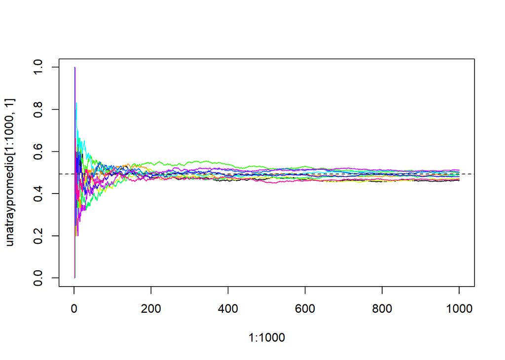

```r
plot(1:1000,unatraypromedio[1:1000,1],type="l",ylim = c(0,1))
for(j in 2:10){
  points(1:1000,unatraypromedio[1:1000,j],type="l",
         col=rainbow(10)[j])}
abline(h=0.4927,lty=2)
```

Graficamos 10 trayectorias de los promedios, con n entre 1 y 5000

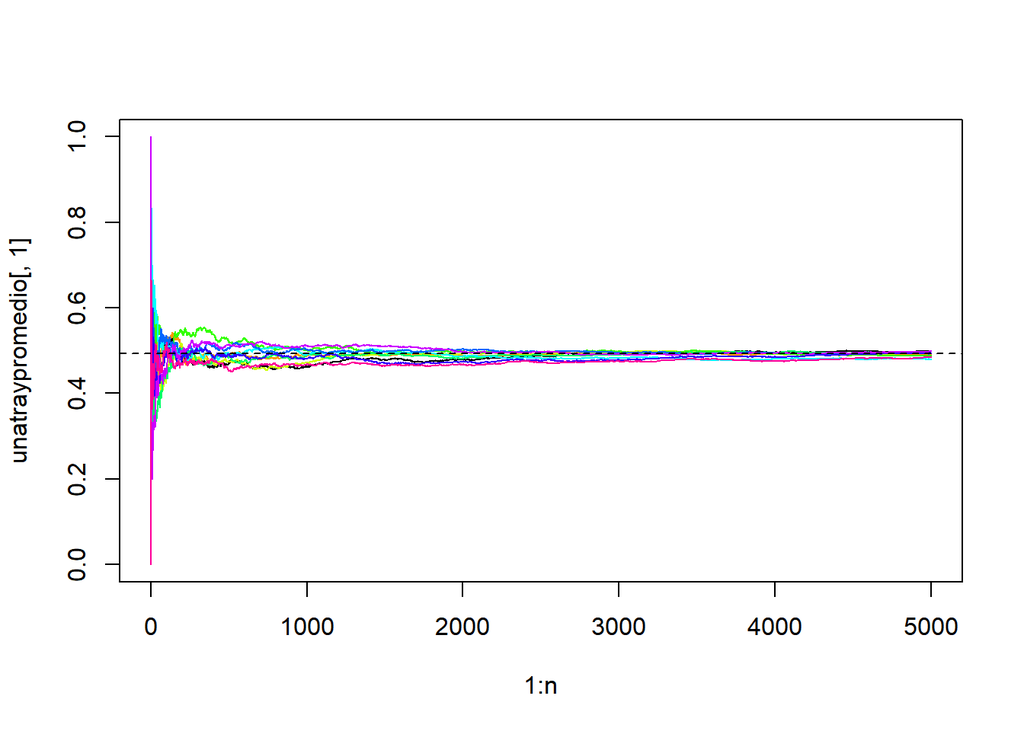

```r
plot(1:n,unatraypromedio[,1],type="l",ylim = c(0,1))
for(j in 2:10){
points(1:n,unatraypromedio[,j],type="l",col=rainbow(10)[j])}
abline(h=0.4927,lty=2)
```

## Histogramas de promedios, fijando el eje x en (0,1)

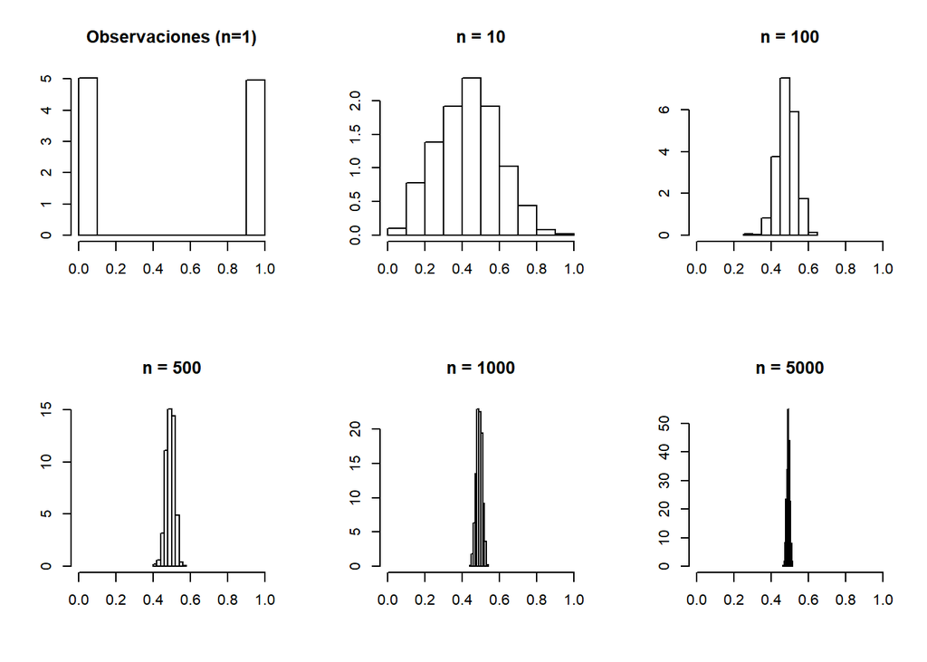

```r
par(mfrow=c(2,3))
hist(unatraypromedio[1,],xlim = c(0,1),main = "Observaciones (n=1)",
     xlab="",ylab = "",freq = F)
hist(unatraypromedio[10,],xlim = c(0,1),main = "n = 10",
     xlab="",ylab = "",freq = F)
hist(unatraypromedio[100,],xlim = c(0,1),main = "n = 100",
     xlab="",ylab = "",freq = F)
hist(unatraypromedio[500,],xlim = c(0,1),main = "n = 500",
     xlab="",ylab = "",freq = F)
hist(unatraypromedio[1000,],xlim = c(0,1),main = "n = 1000",
     xlab="",ylab = "",freq = F)
hist(unatraypromedio[5000,],xlim = c(0,1),main = "n = 5000",
     xlab="",ylab = "",freq = F)
```

## Histogramas de promedios, moviendo la escala del eje x

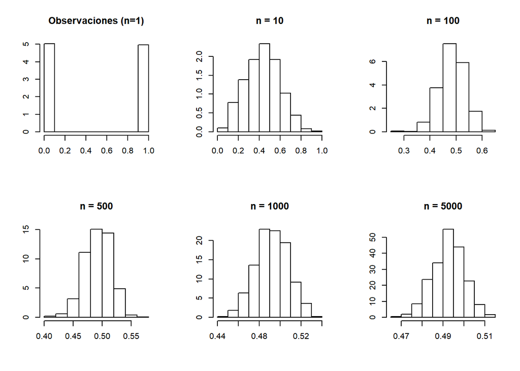

```r
par(mfrow=c(2,3))
hist(unatraypromedio[1,],main = "Observaciones (n=1)",
     xlab="",ylab = "",freq = F)
hist(unatraypromedio[10,],main = "n = 10",
     xlab="",ylab = "",freq = F)
hist(unatraypromedio[100,],main = "n = 100",
     xlab="",ylab = "",freq = F)
hist(unatraypromedio[500,],main = "n = 500",
     xlab="",ylab = "",freq = F)
hist(unatraypromedio[1000,],main = "n = 1000",
     xlab="",ylab = "",freq = F)
hist(unatraypromedio[5000,],main = "n = 5000",
     xlab="",ylab = "",freq = F)
```